Griffin Shelor  
4-3-2024

# In-class Exercises Numpy Part 2

```python
import numpy as np
import matplotlib.pyplot as plt
```

### Q1. Load data from the file `lecture11_vel_sedthick.csv` into two `numpy` `arrays`

- The file has one header row that you should skip
- The file uses ',' as a `delimiter`
- First column is seismic velocity in a geologic layer right below the sediment-basement interface in oceanic crust
- Second column is the corresponding sediment thickness above this layer

```python
velocity, sed_thick = np.loadtxt('lecture11_vel_sedthick.csv', delimiter=',', skiprows=1, unpack=True)
```

### Q2. Make a plot with velocity on the x-axis and sediment thickness on the y-axis. Use markers (not a standard line plot) and label the axes.

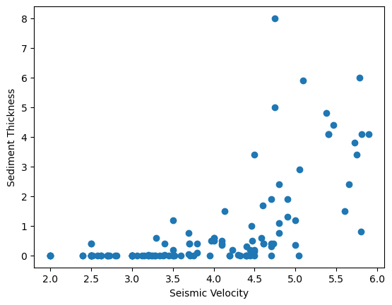

```python
plt.plot(velocity, sed_thick, 'o')
plt.xlabel('Seismic Velocity')
plt.ylabel('Sediment Thickness');
```

### Q3. Fit the data with a polynomial of an appropriate degree (you decide), and make the same plot as Q2, but add the polynomial fit as a line. Include a legend on the plot.

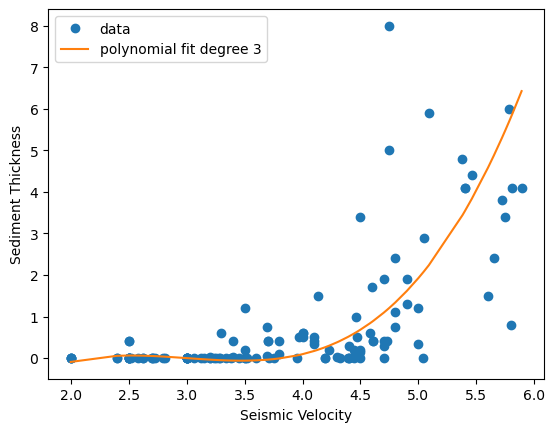

```python
## fitting polynomial
## sorting data
velocity_sort = np.sort(velocity)
sed_thick_sort = np.sort(sed_thick)
data_fit = np.polyfit(velocity_sort, sed_thick_sort, 3)
y_calc = np.polyval(data_fit, velocity_sort)

plt.plot(velocity, sed_thick, 'o', label = 'data')
plt.plot(velocity_sort, y_calc, "-", label='polynomial fit degree 3')
plt.xlabel('Seismic Velocity')
plt.ylabel('Sediment Thickness')
plt.legend(loc = 'best');
```

### Q4. Use `np.select` to create an `array` that has the value 'thin' if sediment thickness is less than 1 km, 'normal' if sediment thickness is between 1-3.5 km, and 'thick' if sediment thickness is greater than 3.5 km.

```python
## setting conditions for selection
conditions = [(sed_thick < 1),
              ((sed_thick >= 1) & (sed_thick < 3.5)),
              (sed_thick >= 3.5)]
## setting categories for each condition
categories = ['thin', 'normal', 'thick']
sed_thick_cat = np.select(conditions, categories)
print(sed_thick_cat)
```

```
['thin' 'thin' 'thick' 'thick' 'thick' 'thin' 'thin' 'thin' 'thin' 'thin'
 'thin' 'thin' 'thin' 'thin' 'thin' 'thin' 'thin' 'thin' 'thin' 'normal'
 'thin' 'thin' 'thin' 'thin' 'normal' 'thin' 'thin' 'thin' 'thin' 'thin'
 'thin' 'thin' 'normal' 'normal' 'normal' 'normal' 'thin' 'thin' 'thin'
 'thin' 'thin' 'thin' 'thin' 'thin' 'thin' 'thin' 'thin' 'thin' 'thin'
 'thin' 'thin' 'thin' 'thin' 'thin' 'thin' 'thin' 'thin' 'thin' 'thin'
 'thin' 'thin' 'thin' 'thick' 'thick' 'thin' 'thin' 'thin' 'normal'
 'normal' 'thin' 'thin' 'thin' 'thin' 'thin' 'normal' 'thick' 'thin'
 'thick' 'normal' 'normal' 'thin' 'thin' 'thin' 'thin' 'thin' 'thin'
 'thin' 'thin' 'thin' 'normal' 'thin' 'thin' 'thin' 'thin' 'thin' 'thin'
 'normal' 'thin' 'thin' 'thin' 'thin' 'thin' 'thin' 'thin' 'thin' 'thin'
 'thin' 'thin' 'thin' 'thin' 'thin' 'thin' 'thin' 'thin' 'thin' 'normal'
 'thick' 'thick' 'normal' 'thick' 'thick']
```

### Q5. What are the mean and standard deviation of sediment thickness measurements? What are the mean and standard deviation of the velocity measurements?

```python
sed_thick_mean = np.mean(sed_thick)
sed_thick_sd = np.std(sed_thick)
print(sed_thick_mean, sed_thick_sd)

velocity_mean = np.mean(velocity)
velocity_sd = np.std(velocity)
print(velocity_mean, velocity_sd)
```

```
0.7988429752066116 1.514938391722619
3.8532231404958677 1.0046710862419765
```

### Q6. Make an `array` that has the velocity sorted by increasing velocity, and a second `array` that has the sediment thicknesses corresponding to these sorted velocity values.

```python
## sorting data
velocity_sort_ind = np.argsort(velocity)
# print(velocity_sort_ind)
velocity_sort = velocity[velocity_sort_ind]
print(velocity_sort)
sed_thick_sort = sed_thick[velocity_sort_ind]
print(sed_thick_sort)
```

```
[2.   2.   2.   2.   2.4  2.4  2.5  2.5  2.5  2.5  2.5  2.5  2.5  2.5
 2.52 2.58 2.62 2.62 2.7  2.7  2.71 2.73 2.8  2.81 3.   3.   3.   3.
 3.   3.   3.   3.   3.06 3.12 3.15 3.2  3.2  3.2  3.24 3.25 3.28 3.29
 3.3  3.34 3.38 3.4  3.4  3.45 3.5  3.5  3.5  3.5  3.52 3.6  3.69 3.69
 3.7  3.7  3.71 3.75 3.8  3.8  3.95 3.97 4.   4.   4.   4.1  4.1  4.1
 4.13 4.19 4.19 4.23 4.3  4.32 4.39 4.4  4.4  4.4  4.44 4.44 4.46 4.47
 4.5  4.5  4.5  4.5  4.58 4.6  4.61 4.61 4.7  4.7  4.7  4.7  4.73 4.75
 4.75 4.8  4.8  4.8  4.9  4.9  5.   5.   5.04 5.05 5.09 5.38 5.4  5.4
 5.46 5.6  5.65 5.72 5.75 5.78 5.8  5.81 5.89]
[0.   0.   0.   0.   0.   0.   0.4  0.   0.   0.   0.4  0.   0.   0.
 0.   0.   0.   0.   0.   0.   0.   0.   0.   0.   0.   0.   0.   0.
 0.   0.   0.   0.   0.   0.   0.   0.   0.02 0.   0.   0.   0.   0.
 0.6  0.   0.   0.4  0.02 0.   0.2  0.   0.   1.2  0.   0.   0.75 0.04
 0.4  0.4  0.   0.   0.4  0.1  0.   0.5  0.6  0.6  0.5  0.5  0.35 0.4
 1.5  0.   0.   0.2  0.03 0.   0.   0.   0.3  0.   0.2  0.   1.   0.5
 0.   0.2  3.4  0.15 0.6  1.7  0.4  0.4  1.9  0.4  0.   0.3  0.4  5.
 8.   1.1  2.4  0.75 1.9  1.3  0.35 1.2  0.   2.9  5.9  4.8  4.1  4.1
 4.4  1.5  2.4  3.8  3.4  6.   0.8  4.1  4.1 ]
```

### Save your notebook and output an html version. To receive credit for this in-class exercise upload both the .html and .ipynb files.